# R: Dates, Factors, Lists, Help

Christina Maimone

```r
library(tidyverse)
```

# Dates

In most cases, when you read data with dates/times in it into R, it will be read in as character (text) data:

```r
evp <- read.csv("data/ev_police_jan.csv")
str(evp)
```

```
## 'data.frame':    1409 obs. of  29 variables:
##  $ raw_row_number           : int  11249746 11249747 11249748 11249749 11249750 11249751 11249752 11249753 11249754 11249755 ...
##  $ date                     : chr  "2017-01-01" "2017-01-01" "2017-01-01" "2017-01-01" ...
##  $ time                     : chr  "00:56:00" "04:43:00" "09:21:00" "10:04:00" ...
##  $ location                 : int  60202 60643 60625 60068 60645 60645 60626 60202 60656 60626 ...
##  $ beat                     : chr  "72" "71" "78" "75" ...
##  $ subject_age              : logi  NA NA NA NA NA NA ...
##  $ subject_race             : chr  "white" "black" "black" "white" ...
##  $ subject_sex              : chr  "male" "male" "female" "male" ...
##  $ department_id            : int  13178 13178 13178 13178 13178 13178 13178 13178 13178 13178 ...
##  $ department_name          : chr  "EVANSTON POLICE" "EVANSTON POLICE" "EVANSTON POLICE" "EVANSTON POLICE" ...
##  $ type                     : chr  "vehicular" "vehicular" "vehicular" "vehicular" ...
##  $ violation                : chr  "Moving Violation: Traffic Sign or Signal" "Equipment" "License Plate/Registration" "Moving Violation: Traffic Sign or Signal" ...
##  $ citation_issued          : logi  FALSE FALSE FALSE FALSE TRUE TRUE ...
##  $ warning_issued           : logi  TRUE TRUE TRUE TRUE FALSE FALSE ...
##  $ outcome                  : chr  "warning" "warning" "warning" "warning" ...
##  $ contraband_found         : logi  NA NA NA NA NA NA ...
##  $ contraband_drugs         : logi  NA NA NA NA NA NA ...
##  $ contraband_weapons       : logi  NA NA NA NA NA NA ...
##  $ search_conducted         : logi  FALSE FALSE FALSE FALSE FALSE FALSE ...
##  $ search_person            : logi  FALSE FALSE FALSE FALSE FALSE FALSE ...
##  $ search_vehicle           : logi  FALSE FALSE FALSE FALSE FALSE FALSE ...
##  $ search_basis             : chr  NA NA NA NA ...
##  $ reason_for_stop          : chr  "Moving Violation: Traffic Sign or Signal" "Equipment" "License Plate/Registration" "Moving Violation: Traffic Sign or Signal" ...
##  $ vehicle_make             : chr  "TOYT" "NISS" "CHEV" "NISS" ...
##  $ vehicle_year             : int  2006 2015 2011 2009 2010 2005 2011 2009 2007 2011 ...
##  $ raw_DriverRace           : int  1 2 2 1 1 1 2 1 1 2 ...
##  $ raw_ReasonForStop        : int  1 2 3 1 1 1 1 1 1 1 ...
##  $ raw_TypeOfMovingViolation: int  4 0 0 4 1 6 3 1 1 1 ...
##  $ raw_ResultOfStop         : int  3 3 3 2 1 1 1 2 2 2 ...
```

Note: Evanston police data comes from the [Stanford Open Policing Project](https://openpolicing.stanford.edu/data/). This is a small subset of data: just January 2017.

Note: if you use the readr package to import your data, it will try to convert things that look like dates to Date objects if it can; you can also specify that a column contains dates/times when you import the data with the readr package.

If you want to use this information in a visualization, or aggregate data by month, or use the date information in other ways, you’ll need to convert this information into an object that knows about dates and times.

The easiest way to do this is with the lubridate package (part of tidyverse).

```r
library(lubridate)
```

It has a series of functions that are named like:

```r
ymd()
ymd_hms()
dmy()
dmy_h()
mdy()
```

And so on, where y=year, m (in the first part)=month, d=day, h=hour, m (in the second part)=minute, s=second. With the function name, you are specifying which parts of a date or time appear in the text you’re converting and what order the different parts appear in. You can ignore all of the delimiters and other components like dashes, slashes, or even no delimiter at all. lubridate can handle most cases:

```r
my_dates <- c("1/13/2020","1/13/20", "01132020", "1-13-2020", "Jan 13 2020", "Jan. 13, 2020")
class(my_dates)
```

```
## [1] "character"
```

```r
my_dates <- mdy(my_dates)
class(my_dates)
```

```
## [1] "Date"
```

Without lubridate, you have to specify the format of the datetime object with POSIX standards (see the help page for strftime).

## EXERCISE

Make two new columns in the evp data frame:

- Date (capitalized) that converts the date column to a Date type
- datetime: paste (concatenate) the date and time columns together, and then convert the joined string to a datetime object (it will be of type “POSIXct”)

The command to paste the two columns together is provided to get you started.

```r
paste(evp$date, evp$time)
```

## Example

Now that we have the data information in a date-type format, we can ask questions such as: what day of the week had the most traffic stops?

```r
wday(evp$Date, label=TRUE)  # day of the week of the stop (named)
table(wday(evp$Date, label=TRUE))  # tally these
```

The data we have is just for January, which means there are more instances of some days of the week than others. So we want to normalize by the number of Mondays, Tuesdays, etc.

```r
seq.Date(ymd("2017-01-01"), ymd("2017-01-31"), 1)  # days in January 2017
wday(seq.Date(ymd("2017-01-01"), ymd("2017-01-31"), 1), label=TRUE)  ## as days of the week
table(wday(seq.Date(ymd("2017-01-01"), ymd("2017-01-31"), 1), label=TRUE))  # tallied
table(wday(evp$Date, label=TRUE)) / table(wday(seq.Date(ymd("2017-01-01"), ymd("2017-01-31"), 1), label=TRUE)) # together
```

# Factors

Factors are variables with text labels, but the set of values (called levels) that are allowed for the variable is limited, and the values optionally can have a specific order to them.

## Why Do I Need Factors?

Let’s look at what happens with the days of the week if they are NOT a factor – just character (text) data instead:

```r
evp$Date <- ymd(evp$date)  # did this in the exercise above
evp$dow <- as.character(wday(evp$Date, label=TRUE))
table(evp$dow)
```

```
##
## Fri Mon Sat Sun Thu Tue Wed
## 213 235 173 142 179 270 197
```

The days are in alphabetical order, not day of the week order!

Or, let’s make a plot of the reported race of of the people stopped:

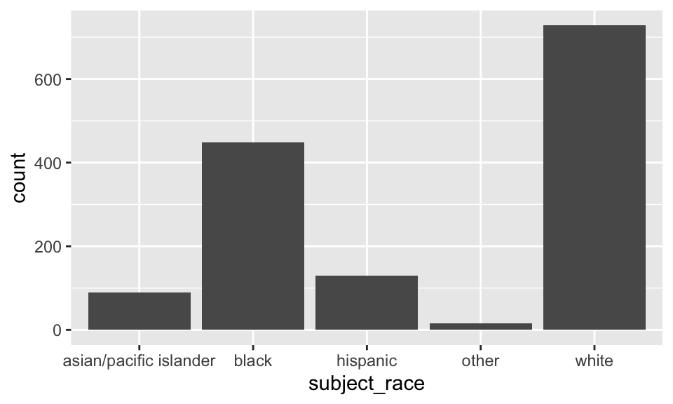

```r
ggplot(evp, aes(x=subject_race)) +
  geom_bar()
```

This is OK, but ideally the categories of a bar chart would either be in a meaningful order, or ordered by their frequency.

## Make a Factor

In both cases above, the character data is converted into a factor in the process of making a table or the plot. If we don’t like the default ordering, we can control it by explicitly making the variable a factor ourselves and setting the levels.

The default order is alphabetical order, which is dependent on the locale of your computer (language and location settings).

```r
evp$subject_race <- factor(evp$subject_race,
                           levels=c("white", "black", "hispanic", "asian/pacific islander", "other"))
head(evp$subject_race)
```

```
## [1] white black black white white white
## Levels: white black hispanic asian/pacific islander other
```

```r
table(evp$subject_race)
```

```
##
##                  white                  black               hispanic asian/pacific islander                  other
##                    728                    448                    129                     89                     15
```

Here, we specified the levels in order, so they will appear that way. But we didn’t say that any category is greater than or less than another – there isn’t an inherit order to the categories. In cases that there is an order, we can provide that information as well. I have found very few cases where I need to do this in practice, however.

```r
answers <- c("Very unhappy", "Somewhat unhappy", "Somewhat happy", "Very happy",
             "Somewhat unhappy", "Somewhat happy", "Somewhat unhappy", "Somewhat happy",
             "Very happy", "Very unhappy", "Very happy", "Very happy")
answers <- factor(answers,
                  levels = c("Very unhappy", "Somewhat unhappy", "Somewhat happy", "Very happy"),
                  ordered = TRUE)
answers
```

```
##  [1] Very unhappy     Somewhat unhappy Somewhat happy   Very happy       Somewhat unhappy Somewhat happy   Somewhat unhappy
##  [8] Somewhat happy   Very happy       Very unhappy     Very happy       Very happy
## Levels: Very unhappy < Somewhat unhappy < Somewhat happy < Very happy
```

You can see here that the levels are printed with less than signs `<` indicating a formal ordering that can be used in boolean comparisons.

## EXERCISE

Convert the vector below to a factor. Set the levels in an intentional order.

```r
directions <- c("east", "west", "east", "south", "north", "north", "west", "north", "east")
```

## forcats Package

The forcats package has a number of functions to help you work with factors – for example, reordering the levels of a factor based on the frequency of the levels, combining low-frequency categories into an “other” category, and dealing with missing values.

With our bar plot above, we could have used the forcats package to re-order our categories in frequency order:

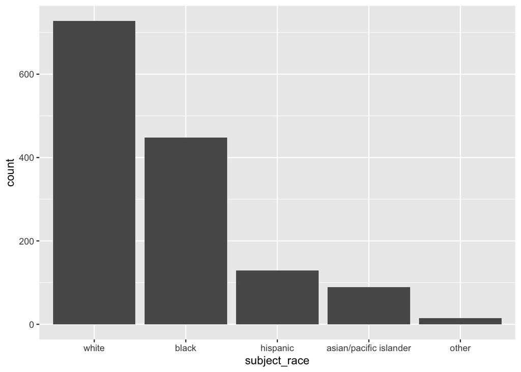

```r
evp$subject_race <- forcats::fct_infreq(evp$subject_race)
ggplot(evp, aes(x=subject_race)) +
  geom_bar()
```

## Caution

If you try to change the value of a variable that is a factor to something that isn’t one of the factor levels, you will introduce missing values into your data:

```r
my_colors <- factor(c("red", "blue", "green", "red", "red", "blue", "green"))
my_colors
```

```
## [1] red   blue  green red   red   blue  green
## Levels: blue green red
```

```r
my_colors[1] <- "pink"
my_colors
```

```
## [1] <NA>  blue  green red   red   blue  green
## Levels: blue green red
```

To avoid this issue, usually the easiest thing to do is to convert the variable to be of character type before changing the values, and then re-make the factor if you need:

```r
my_colors <- as.character(my_colors)
my_colors[1] <- "pink"
my_colors <- factor(my_colors)
my_colors
```

```
## [1] pink  blue  green red   red   blue  green
## Levels: blue green pink red
```

Also, the default order for factors can be different in different places in the world. To avoid this issue, either explicitly set the levels for any factor you create or use the forcats package to create a factor instead of the default `factor()` function.

# Lists

Lists allow us to store many different types of data to be stored together. The most common uses of lists I see in R are for storing

- multiple data frames together in one object (so you can do the same thing to many different data frames with one command)
- vectors of varying lengths
- hierarchical data from JSON files or similar files (although there are special packages to work with this type of data)
- result of a function call that can have output of varying lengths (i.e. `strsplit()`)

Our goals are to:

1. Recognize a list
2. Access elements in a list

Normally, we’d have a list as a result of some other operation. Here, I’m making a simple one manually to work with that uses some of the built-in vectors and data sets in R:

```r
state_data <- list(date_created="2021-12-08",        # single value
                   names = state.name,               # vector
                   abb = state.abb,                  # vector
                   vars = as.data.frame(state.x77),  # data frame
                   center = state.center,            # list
                   "From R built-in datasets")       # single value, unnamed element
state_data
```

```
## $date_created
## [1] "2021-12-08"
##
## $names
##  [1] "Alabama"        "Alaska"         "Arizona"        "Arkansas"       "California"     "Colorado"       "Connecticut"
##  [8] "Delaware"       "Florida"        "Georgia"        "Hawaii"         "Idaho"          "Illinois"       "Indiana"
## [15] "Iowa"           "Kansas"         "Kentucky"       "Louisiana"      "Maine"          "Maryland"       "Massachusetts"
## [22] "Michigan"       "Minnesota"      "Mississippi"    "Missouri"       "Montana"        "Nebraska"       "Nevada"
## [29] "New Hampshire"  "New Jersey"     "New Mexico"     "New York"       "North Carolina" "North Dakota"   "Ohio"
## [36] "Oklahoma"       "Oregon"         "Pennsylvania"   "Rhode Island"   "South Carolina" "South Dakota"   "Tennessee"
## [43] "Texas"          "Utah"           "Vermont"        "Virginia"       "Washington"     "West Virginia"  "Wisconsin"
## [50] "Wyoming"
##
## $abb
##  [1] "AL" "AK" "AZ" "AR" "CA" "CO" "CT" "DE" "FL" "GA" "HI" "ID" "IL" "IN" "IA" "KS" "KY" "LA" "ME" "MD" "MA" "MI" "MN" "MS" "MO" "MT"
## [27] "NE" "NV" "NH" "NJ" "NM" "NY" "NC" "ND" "OH" "OK" "OR" "PA" "RI" "SC" "SD" "TN" "TX" "UT" "VT" "VA" "WA" "WV" "WI" "WY"
##
## $vars
##                Population Income Illiteracy Life Exp Murder HS Grad Frost   Area
## Alabama              3615   3624        2.1    69.05   15.1    41.3    20  50708
## Alaska                365   6315        1.5    69.31   11.3    66.7   152 566432
## Arizona              2212   4530        1.8    70.55    7.8    58.1    15 113417
## Arkansas             2110   3378        1.9    70.66   10.1    39.9    65  51945
## California          21198   5114        1.1    71.71   10.3    62.6    20 156361
## Colorado             2541   4884        0.7    72.06    6.8    63.9   166 103766
## Connecticut          3100   5348        1.1    72.48    3.1    56.0   139   4862
## Delaware              579   4809        0.9    70.06    6.2    54.6   103   1982
## Florida              8277   4815        1.3    70.66   10.7    52.6    11  54090
## Georgia              4931   4091        2.0    68.54   13.9    40.6    60  58073
## Hawaii                868   4963        1.9    73.60    6.2    61.9     0   6425
## Idaho                 813   4119        0.6    71.87    5.3    59.5   126  82677
## Illinois            11197   5107        0.9    70.14   10.3    52.6   127  55748
## Indiana              5313   4458        0.7    70.88    7.1    52.9   122  36097
## Iowa                 2861   4628        0.5    72.56    2.3    59.0   140  55941
## Kansas               2280   4669        0.6    72.58    4.5    59.9   114  81787
## Kentucky             3387   3712        1.6    70.10   10.6    38.5    95  39650
## Louisiana            3806   3545        2.8    68.76   13.2    42.2    12  44930
## Maine                1058   3694        0.7    70.39    2.7    54.7   161  30920
## Maryland             4122   5299        0.9    70.22    8.5    52.3   101   9891
## Massachusetts        5814   4755        1.1    71.83    3.3    58.5   103   7826
```

[output cut: 31 more lines]

```
## $center$x
##  [1]  -86.7509 -127.2500 -111.6250  -92.2992 -119.7730 -105.5130  -72.3573  -74.9841  -81.6850  -83.3736 -126.2500 -113.9300  -89.3776
## [14]  -86.0808  -93.3714  -98.1156  -84.7674  -92.2724  -68.9801  -76.6459  -71.5800  -84.6870  -94.6043  -89.8065  -92.5137 -109.3200
## [27]  -99.5898 -116.8510  -71.3924  -74.2336 -105.9420  -75.1449  -78.4686 -100.0990  -82.5963  -97.1239 -120.0680  -77.4500  -71.1244
## [40]  -80.5056  -99.7238  -86.4560  -98.7857 -111.3300  -72.5450  -78.2005 -119.7460  -80.6665  -89.9941 -107.2560
##
## $center$y
##  [1] 32.5901 49.2500 34.2192 34.7336 36.5341 38.6777 41.5928 38.6777 27.8744 32.3329 31.7500 43.5648 40.0495 40.0495 41.9358 38.4204
## [17] 37.3915 30.6181 45.6226 39.2778 42.3645 43.1361 46.3943 32.6758 38.3347 46.8230 41.3356 39.1063 43.3934 39.9637 34.4764 43.1361
## [33] 35.4195 47.2517 40.2210 35.5053 43.9078 40.9069 41.5928 33.6190 44.3365 35.6767 31.3897 39.1063 44.2508 37.5630 47.4231 38.4204
## [49] 44.5937 43.0504
##
##
## [[6]]
## [1] "From R built-in datasets"
```

When it prints, you can see that it prints the names of the elements after a `$`. For elements that don’t have a name, it prints the index position in double brackets: `[[]]`

How many elements are in the list (at the top level)

```r
length(state_data)
```

```
## [1] 6
```

We can access the elements of the list by name with the `$` notation:

```r
state_data$names
```

```
##  [1] "Alabama"        "Alaska"         "Arizona"        "Arkansas"       "California"     "Colorado"       "Connecticut"
##  [8] "Delaware"       "Florida"        "Georgia"        "Hawaii"         "Idaho"          "Illinois"       "Indiana"
## [15] "Iowa"           "Kansas"         "Kentucky"       "Louisiana"      "Maine"          "Maryland"       "Massachusetts"
## [22] "Michigan"       "Minnesota"      "Mississippi"    "Missouri"       "Montana"        "Nebraska"       "Nevada"
## [29] "New Hampshire"  "New Jersey"     "New Mexico"     "New York"       "North Carolina" "North Dakota"   "Ohio"
## [36] "Oklahoma"       "Oregon"         "Pennsylvania"   "Rhode Island"   "South Carolina" "South Dakota"   "Tennessee"
## [43] "Texas"          "Utah"           "Vermont"        "Virginia"       "Washington"     "West Virginia"  "Wisconsin"
## [50] "Wyoming"
```

When this prints, there is no name in the output – we’ve extracted the element from the list.

We can also access the elements of the list by index position. If we use single brackets:

```r
state_data[1]
```

```
## $date_created
## [1] "2021-12-08"
```

what we get back is still a list:

```r
class(state_data[1])
```

```
## [1] "list"
```

If we want what’s in that position instead, we need to use double brackets:

```r
state_data[[1]]
```

```
## [1] "2021-12-08"
```

When the element we want to access also has it’s own parts, we can keep adding on brackets (or `$`):

```r
state_data[[5]]
```

```
## $x
##  [1]  -86.7509 -127.2500 -111.6250  -92.2992 -119.7730 -105.5130  -72.3573  -74.9841  -81.6850  -83.3736 -126.2500 -113.9300  -89.3776
## [14]  -86.0808  -93.3714  -98.1156  -84.7674  -92.2724  -68.9801  -76.6459  -71.5800  -84.6870  -94.6043  -89.8065  -92.5137 -109.3200
## [27]  -99.5898 -116.8510  -71.3924  -74.2336 -105.9420  -75.1449  -78.4686 -100.0990  -82.5963  -97.1239 -120.0680  -77.4500  -71.1244
## [40]  -80.5056  -99.7238  -86.4560  -98.7857 -111.3300  -72.5450  -78.2005 -119.7460  -80.6665  -89.9941 -107.2560
##
## $y
##  [1] 32.5901 49.2500 34.2192 34.7336 36.5341 38.6777 41.5928 38.6777 27.8744 32.3329 31.7500 43.5648 40.0495 40.0495 41.9358 38.4204
## [17] 37.3915 30.6181 45.6226 39.2778 42.3645 43.1361 46.3943 32.6758 38.3347 46.8230 41.3356 39.1063 43.3934 39.9637 34.4764 43.1361
## [33] 35.4195 47.2517 40.2210 35.5053 43.9078 40.9069 41.5928 33.6190 44.3365 35.6767 31.3897 39.1063 44.2508 37.5630 47.4231 38.4204
## [49] 44.5937 43.0504
```

```r
state_data[[5]][1]
```

```
## $x
##  [1]  -86.7509 -127.2500 -111.6250  -92.2992 -119.7730 -105.5130  -72.3573  -74.9841  -81.6850  -83.3736 -126.2500 -113.9300  -89.3776
## [14]  -86.0808  -93.3714  -98.1156  -84.7674  -92.2724  -68.9801  -76.6459  -71.5800  -84.6870  -94.6043  -89.8065  -92.5137 -109.3200
## [27]  -99.5898 -116.8510  -71.3924  -74.2336 -105.9420  -75.1449  -78.4686 -100.0990  -82.5963  -97.1239 -120.0680  -77.4500  -71.1244
## [40]  -80.5056  -99.7238  -86.4560  -98.7857 -111.3300  -72.5450  -78.2005 -119.7460  -80.6665  -89.9941 -107.2560
```

```r
state_data[[5]][[1]]
```

```
##  [1]  -86.7509 -127.2500 -111.6250  -92.2992 -119.7730 -105.5130  -72.3573  -74.9841  -81.6850  -83.3736 -126.2500 -113.9300  -89.3776
## [14]  -86.0808  -93.3714  -98.1156  -84.7674  -92.2724  -68.9801  -76.6459  -71.5800  -84.6870  -94.6043  -89.8065  -92.5137 -109.3200
## [27]  -99.5898 -116.8510  -71.3924  -74.2336 -105.9420  -75.1449  -78.4686 -100.0990  -82.5963  -97.1239 -120.0680  -77.4500  -71.1244
## [40]  -80.5056  -99.7238  -86.4560  -98.7857 -111.3300  -72.5450  -78.2005 -119.7460  -80.6665  -89.9941 -107.2560
```

```r
state_data[[5]]$x
```

```
##  [1]  -86.7509 -127.2500 -111.6250  -92.2992 -119.7730 -105.5130  -72.3573  -74.9841  -81.6850  -83.3736 -126.2500 -113.9300  -89.3776
## [14]  -86.0808  -93.3714  -98.1156  -84.7674  -92.2724  -68.9801  -76.6459  -71.5800  -84.6870  -94.6043  -89.8065  -92.5137 -109.3200
## [27]  -99.5898 -116.8510  -71.3924  -74.2336 -105.9420  -75.1449  -78.4686 -100.0990  -82.5963  -97.1239 -120.0680  -77.4500  -71.1244
## [40]  -80.5056  -99.7238  -86.4560  -98.7857 -111.3300  -72.5450  -78.2005 -119.7460  -80.6665  -89.9941 -107.2560
```

We can iterate over lists to do the same thing (apply the same function) to every element:

```r
sapply(state_data, length)
```

```
## date_created        names          abb         vars       center
##            1           50           50            8            2            1
```

If you want to do more with lists, look at the purrr package. There are multiple tutorials available online.

## EXERCISE

What is the median Area of US states? Hint: There’s an Area variable in the data frame that’s in the “vars” element of the state_data list. There’s also a `median()` function.

## Objects

Objects are used in R to store complex information. One type of object you may have seen is the result of running a regression model.

```r
reg1 <- lm(mpg ~ hp + wt, data=mtcars)  # mtcars is a built-in data set
reg1
```

```
##
## Call:
## lm(formula = mpg ~ hp + wt, data = mtcars)
##
## Coefficients:
## (Intercept)           hp           wt
##    37.22727     -0.03177     -3.87783
```

You can access the components of these objects as you would with a list:

```r
names(reg1)
```

```
##  [1] "coefficients"  "residuals"     "effects"       "rank"          "fitted.values" "assign"        "qr"            "df.residual"
##  [9] "xlevels"       "call"          "terms"         "model"
```

```r
reg1$coefficients
```

```
## (Intercept)          hp          wt
## 37.22727012 -0.03177295 -3.87783074
```

```r
reg1[[1]]
```

```
## (Intercept)          hp          wt
## 37.22727012 -0.03177295 -3.87783074
```

The objects have other properties too beyond a standard list – many know how to print a summary of themselves, they may know how to plot themselves, etc.

# Using the R Help

See the `help.pdf` file in the materials.

We’re going to talk through the page for `read.csv()`.

## EXERCISE

Do the first part below where you’re unfamiliar with the function

### Part A: table

Look at the help page for `table()` to make a table that also includes the count of any missing values in the vector x.

Bonus: after you do that, look up the help for the `sample()` function to see what’s going on there :)

```r
x <- sample(c(letters[1:10], NA, NA, NA), 100, TRUE)
```

### Part B: quantile

Use the `quantile()` function to find the 50th (0.5) and 95th (.95) quantiles of the x vector below. Look up the help for the function to see how to use it.

```r
x <- rnorm(100)
```

### Part C: list.files

Use the `list.files()` function to list all files in your working directory that end with “.R”. Look up the help for the function to see how to use it.

Hint: “.R” will include files where the extension starts with “.R” but may have more, such as “.Rmd”. To get just the “.R” files, use the pattern “.R$”

Didn’t find any “.R” files? See what other files are in your working directory instead. You can also check what your working directory is with `getwd()`

# Question Time!

What are things you’ve wondered about R?

What are things you find difficult to do?

What’s confusing?

# Bonus: Useful functions

A few useful functions that I use frequently that weren’t covered elsewhere.

## ifelse

`ifelse()` allows you to change the values of a vector based on a conditional test. It’s useful for recoding data, and you can use it in situations where you don’t want to change the underlying data.

```r
x <- c(-1, 2, 3, -5, 3, NA, -4, 6)
ifelse(x >= 0, x, 0)  # replace negative values with 0, leave others alone
```

```
## [1]  0  2  3  0  3 NA  0  6
```

```r
ifelse(is.na(x), 0, x)  # replace missing values with 0, leave others alone
```

```
## [1] -1  2  3 -5  3  0 -4  6
```

```r
ifelse(x %% 2 == 0, "even", "odd")  ## remainder of dividing x by 2 is 0
```

```
## [1] "odd"  "even" "odd"  "odd"  "odd"  NA     "even" "even"
```

There’s also the useful `replace_na()` function in the tidyr package and `na_if()` in dplyr.

## %in%

`%in%` returns TRUE if the value on the left is in the vector on the right, FALSE otherwise. Unlike `==`, if the value on the left is `NA`, it will return FALSE unless `NA` is also in the vector on the right:

```r
x <- c(-1, 2, 3, -5, 3, NA, -4, 6)
x %in% c(1, 2, 3)
```

```
## [1] FALSE  TRUE  TRUE FALSE  TRUE FALSE FALSE FALSE
```

```r
x == 1 | x == 2 | x == 3
```

```
## [1] FALSE  TRUE  TRUE FALSE  TRUE    NA FALSE FALSE
```

```r
state.name
```

```
##  [1] "Alabama"        "Alaska"         "Arizona"        "Arkansas"       "California"     "Colorado"       "Connecticut"
##  [8] "Delaware"       "Florida"        "Georgia"        "Hawaii"         "Idaho"          "Illinois"       "Indiana"
## [15] "Iowa"           "Kansas"         "Kentucky"       "Louisiana"      "Maine"          "Maryland"       "Massachusetts"
## [22] "Michigan"       "Minnesota"      "Mississippi"    "Missouri"       "Montana"        "Nebraska"       "Nevada"
## [29] "New Hampshire"  "New Jersey"     "New Mexico"     "New York"       "North Carolina" "North Dakota"   "Ohio"
## [36] "Oklahoma"       "Oregon"         "Pennsylvania"   "Rhode Island"   "South Carolina" "South Dakota"   "Tennessee"
## [43] "Texas"          "Utah"           "Vermont"        "Virginia"       "Washington"     "West Virginia"  "Wisconsin"
## [50] "Wyoming"
```

```r
ifelse(state.name %in% c("Alaska", "Hawaii"), NA, state.name)
```

```
##  [1] "Alabama"        NA               "Arizona"        "Arkansas"       "California"     "Colorado"       "Connecticut"
##  [8] "Delaware"       "Florida"        "Georgia"        NA               "Idaho"          "Illinois"       "Indiana"
## [15] "Iowa"           "Kansas"         "Kentucky"       "Louisiana"      "Maine"          "Maryland"       "Massachusetts"
## [22] "Michigan"       "Minnesota"      "Mississippi"    "Missouri"       "Montana"        "Nebraska"       "Nevada"
## [29] "New Hampshire"  "New Jersey"     "New Mexico"     "New York"       "North Carolina" "North Dakota"   "Ohio"
## [36] "Oklahoma"       "Oregon"         "Pennsylvania"   "Rhode Island"   "South Carolina" "South Dakota"   "Tennessee"
## [43] "Texas"          "Utah"           "Vermont"        "Virginia"       "Washington"     "West Virginia"  "Wisconsin"
## [50] "Wyoming"
```

## paste0

The `paste()` function is used to join pieces of text:

```r
paste("Christina", "Maimone")
```

```
## [1] "Christina Maimone"
```

The default separator between the strings is a space, but you can change it:

```r
paste("Christina", "Maimone", sep="---")
```

```
## [1] "Christina---Maimone"
```

But, I frequently want to join strings with no space between them:

```r
paste("Christina", "Maimone", sep="")
```

```
## [1] "ChristinaMaimone"
```

There’s a shortcut for this:

```r
paste0("Christina", "Maimone")
```

```
## [1] "ChristinaMaimone"
```

## cat

If you want to print output to the console to copy and paste elsewhere, you may not want quotation marks around strings or the index markers in brackets at the start of the lines. Use `cat()` to print:

```r
cat(1:10, sep=", ")
```

```
## 1, 2, 3, 4, 5, 6, 7, 8, 9, 10
```

```r
cat(letters, sep="\n")
```

```
## a
## b
## c
## d
## e
## f
## g
## h
## i
## j
## k
## l
## m
## n
## o
## p
## q
## r
## s
## t
## u
## v
## w
## x
## y
## z
```